# outputs

Daniel Chen

04/22/2014

# Plotting Function

```r
plot.thesis.data <- function(data, numAgents, numTimeTicks)
  {
  x <- read.csv(data, header=FALSE, stringsAsFactors=FALSE)

  names(x) <- c("time", "agent",
                       "p1", "p2", "p3", "p4", "p5",
                       "n1", "n2", "n3", "n4", "n5")

  print(head(x, numAgents))
  print(tail(x, numAgents))

  for (i in 3:12) {
    x[ ,i] <- as.numeric(x[ ,i])
  }

  x.1 <- x[seq(1, numTimeTicks * numAgents ,numAgents),]
  x.2 <- x[seq(2, numTimeTicks * numAgents ,numAgents),]
  x.3 <- x[seq(3, numTimeTicks * numAgents ,numAgents),]
  x.4 <- x[seq(4, numTimeTicks * numAgents ,numAgents),]
  x.5 <- x[seq(5, numTimeTicks * numAgents ,numAgents),]

  x.1.ave.pos <- apply(x.1[,c(3,4,5,6,7)],1, mean)
  x.1.ave.neg <- apply(x.1[,c(8,9,10,11,12)],1,mean)

  x.2.ave.pos <- apply(x.2[,c(3,4,5,6,7)],1,mean)
  x.2.ave.neg <- apply(x.2[,c(8,9,10,11,12)],1,mean)

  x.3.ave.pos <- apply(x.3[,c(3,4,5,6,7)],1,mean)
  x.3.ave.neg <- apply(x.3[,c(8,9,10,11,12)],1,mean)

  x.4.ave.pos <- apply(x.4[,c(3,4,5,6,7)],1,mean)
  x.4.ave.neg <- apply(x.4[,c(8,9,10,11,12)],1,mean)

  x.5.ave.pos <- apply(x.5[,c(3,4,5,6,7)],1,mean)
  x.5.ave.neg <- apply(x.5[,c(8,9,10,11,12)],1,mean)

  plot(x.1.ave.pos,lty=1,col=1,type="b",ylim=c(0,1))
  lines(x.1.ave.neg, lty=2, col=1, type="b", lwd=3)

  lines(x.2.ave.neg,ylim=c(0,1),lty=1,col=2,type="b")
  lines(x.2.ave.neg,lty=2,col=2,type="b", lwd=3)

  lines(x.3.ave.neg,lty=1,col=3,type="b")
  lines(x.3.ave.neg,lty=2,col=3,type="b", lwd=3)

  lines(x.4.ave.neg,lty=1,col=4,type="b")
  lines(x.4.ave.neg,lty=2,col=4,type="b", lwd=3)

  lines(x.5.ave.neg,lty=1,col=5,type="b")
  lines(x.5.ave.neg,lty=2,col=5,type="b", lwd=3)
  }
```

# Sanity Case:

- Agents Activated: Agent 1 ont
- Valence Bank: positive only
  - Valence bank activation: 1’s
- Valence bank Weights: random
  - opposite 0
  - corresponding 0
  - carry over = 0.2
  - bias = 0
  - decay = -0.5
- Network: circle

```
##    time agent p1   p2   p3   p4   p5 n1 n2 n3 n4 n5
## 1     0     1  1  1.0  1.0  1.0  1.0  0  0  0  0  0
## 2     0     2  0  0.0  0.0  0.0  0.0  0  0  0  0  0
## 3     0     3  0  0.0  0.0  0.0  0.0  0  0  0  0  0
## 4     0     4  0  0.0  0.0  0.0  0.0  0  0  0  0  0
## 5     0     5  0  0.0  0.0  0.0  0.0  0  0  0  0  0
## 6     0     6  0  0.0  0.0  0.0  0.0  0  0  0  0  0
## 7     0     7  0  0.0  0.0  0.0  0.0  0  0  0  0  0
## 8     0     8  0  0.0  0.0  0.0  0.0  0  0  0  0  0
## 9     0     9  0  0.0  0.0  0.0  0.0  0  0  0  0  0
## 10    0    10  0  0.0  0.0  0.0  0.0  0  0  0  0  0
##     time agent    p1                   p2                   p3
## 91     9     1 0.342  0.26913575220118946  0.32144354359437344
## 92     9     2 0.000                  0.0                  0.0
## 93     9     3 0.000                  0.0                  0.0
```

[output cut: 18 more lines]

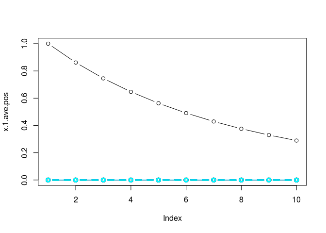

```r
plot.thesis.data("/home/dchen/git/repast-neural-network-agent-based-model/R/data/agent1pos1.csv", 10, 10)
```

# Sanity Case:

- Agents Activated: Agent 1 only
- Valence Bank: positive only
  - Valence bank activation: **random**
- Valence bank Weights: random
  - opposite 0
  - corresponding 0
  - carry over = 0.2
  - bias = 0
  - decay = -0.5
- Network: circle

```
##    time agent            p1            p2            p3            p4
## 1     0     1  0.7751355455  0.3028445595  0.0050462175  0.3106865908
## 2     0     2           0.0           0.0           0.0           0.0
## 3     0     3           0.0           0.0           0.0           0.0
## 4     0     4           0.0           0.0           0.0           0.0
## 5     0     5           0.0           0.0           0.0           0.0
## 6     0     6           0.0           0.0           0.0           0.0
## 7     0     7           0.0           0.0           0.0           0.0
## 8     0     8           0.0           0.0           0.0           0.0
## 9     0     9           0.0           0.0           0.0           0.0
## 10    0    10           0.0           0.0           0.0           0.0
##              p5 n1 n2 n3 n4 n5
## 1   0.092959919  0  0  0  0  0
## 2           0.0  0  0  0  0  0
## 3           0.0  0  0  0  0  0
```

[output cut: 40 more lines]

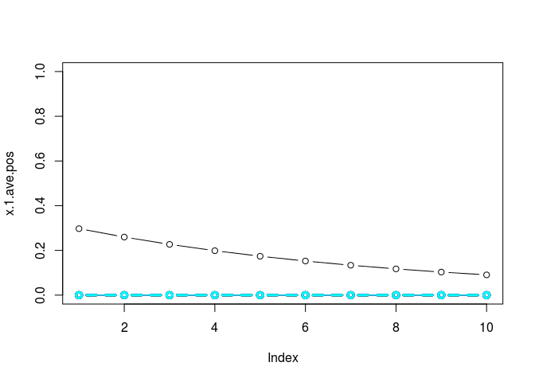

```r
plot.thesis.data("/home/dchen/git/repast-neural-network-agent-based-model/R/data/agent1posrandom.csv", 10, 10)
```

# Sanity Case:

- Agents Activated: Agent 1 only
- Valence Bank: **both**
  - Valence bank activation: random
- Valence bank Weights: random
  - opposite 0
  - corresponding 0
  - carry over = 0.2
  - bias = 0
  - decay = -0.5
- Network: circle

```
##    time agent            p1            p2            p3            p4
## 1     0     1  0.7751355455  0.3028445595  0.0050462175  0.3106865908
## 2     0     2           0.0           0.0           0.0           0.0
## 3     0     3           0.0           0.0           0.0           0.0
## 4     0     4           0.0           0.0           0.0           0.0
## 5     0     5           0.0           0.0           0.0           0.0
## 6     0     6           0.0           0.0           0.0           0.0
## 7     0     7           0.0           0.0           0.0           0.0
## 8     0     8           0.0           0.0           0.0           0.0
## 9     0     9           0.0           0.0           0.0           0.0
## 10    0    10           0.0           0.0           0.0           0.0
##              p5            n1            n2            n3            n4
## 1   0.092959919  0.9741398324  0.7532975646  0.1410541425  0.9262177327
## 2           0.0           0.0           0.0           0.0           0.0
## 3           0.0           0.0           0.0           0.0           0.0
```

[output cut: 62 more lines]

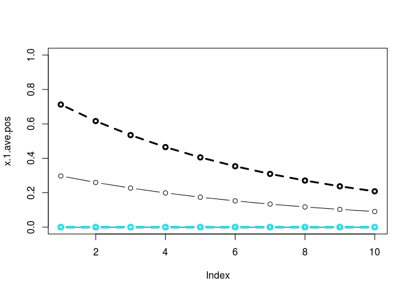

```r
plot.thesis.data("/home/dchen/git/repast-neural-network-agent-based-model/R/data/agent1bothrandom.csv", 10, 10)
```

# Sanity Case:

- Agents Activated: Agent 1 only
- Valence Bank: both
  - Valence bank activation: random
- Valence bank Weights: random
  - opposite **-0.2**
  - corresponding **0.5**
  - carry over = 0.2
  - bias = 0
  - decay = -0.5
- Network: circle

```
##    time agent            p1            p2            p3            p4
## 1     0     1  0.7751355455  0.3028445595  0.0050462175  0.3106865908
## 2     0     2           0.0           0.0           0.0           0.0
## 3     0     3           0.0           0.0           0.0           0.0
## 4     0     4           0.0           0.0           0.0           0.0
## 5     0     5           0.0           0.0           0.0           0.0
## 6     0     6           0.0           0.0           0.0           0.0
## 7     0     7           0.0           0.0           0.0           0.0
## 8     0     8           0.0           0.0           0.0           0.0
## 9     0     9           0.0           0.0           0.0           0.0
## 10    0    10           0.0           0.0           0.0           0.0
##              p5            n1            n2            n3            n4
## 1   0.092959919  0.9741398324  0.7532975646  0.1410541425  0.9262177327
## 2           0.0           0.0           0.0           0.0           0.0
## 3           0.0           0.0           0.0           0.0           0.0
```

[output cut: 73 more lines]

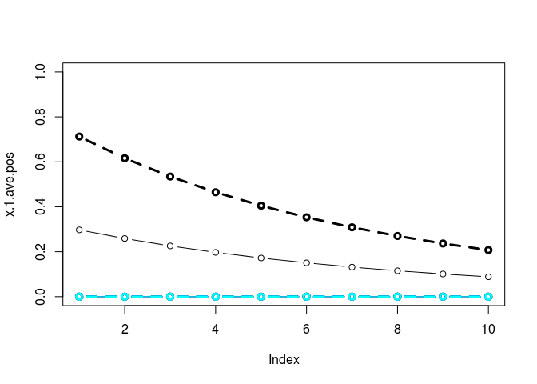

# Sanity Case:

- Agents Activated: **All**
- Valence Bank: both
  - Valence bank activation: random
- Valence bank Weights: random
  - opposite -0.2
  - corresponding 0.5
  - carry over = 0.2
  - bias = 0
  - decay = -0.5
- Network: circle

```
##    time agent            p1            p2            p3            p4
## 1     0     1  0.7751355455  0.3028445595  0.0050462175  0.3106865908
## 2     0     2  0.3625390576  0.9785390012  0.9014779639  0.8058842183
## 3     0     3  0.3986206132  0.1726822082  0.8377374429   0.942544654
## 4     0     4   7.099169E-4  0.8682020768  0.5036309643  0.0236411826
## 5     0     5  0.6989600754  0.9435533623  0.9654612911  0.7025322372
## 6     0     6   0.713820922  0.3321450127  0.7241787538  0.1959324656
## 7     0     7   0.307374656  0.4675681288  0.4750703974  0.1668165834
## 8     0     8  0.0687121372  0.6650054532  0.5003971825  0.0629560116
## 9     0     9  0.3763781996   0.807345853  0.7207107071  0.6581424852
## 10    0    10   0.033716755  0.6983227034  0.7784797847  0.4746849649
##               p5            n1            n2            n3            n4
## 1    0.092959919  0.9741398324  0.7532975646  0.1410541425  0.9262177327
## 2   0.5791122415  0.2541980459  0.1008588905  0.5728363984  0.4968103727
## 3   0.8264983695  0.9032511071  0.4961116214  0.9010971813  0.1842507145
```

[output cut: 62 more lines]

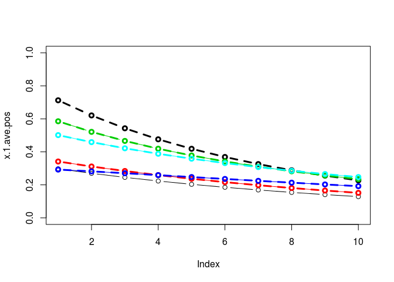

# Output Data

- Agents Activated: 1
- Valence Bank: both
  - Valence bank activation: random
- Valence bank Weights: random
  - opposite -0.2
  - corresponding 0.5
  - carry over = 0.2
  - bias = 0
  - decay = -0.5
- Network: circle
- random number: read in from file
- Processing units per valence bank: 5
- number of agents: 10
- number of time ticks: 10,000

```
##    time agent           p1            p2            p3            p4
## 1     0     1 0.7751355455  0.3028445595  0.0050462175  0.3106865908
## 2     0     2          0.0           0.0           0.0           0.0
## 3     0     3          0.0           0.0           0.0           0.0
## 4     0     4          0.0           0.0           0.0           0.0
## 5     0     5          0.0           0.0           0.0           0.0
## 6     0     6          0.0           0.0           0.0           0.0
## 7     0     7          0.0           0.0           0.0           0.0
## 8     0     8          0.0           0.0           0.0           0.0
## 9     0     9          0.0           0.0           0.0           0.0
## 10    0    10          0.0           0.0           0.0           0.0
##              p5            n1            n2            n3            n4
## 1   0.092959919  0.9741398324  0.7532975646  0.1410541425  0.9262177327
## 2           0.0           0.0           0.0           0.0           0.0
## 3           0.0           0.0           0.0           0.0           0.0
```

[output cut: 62 more lines]

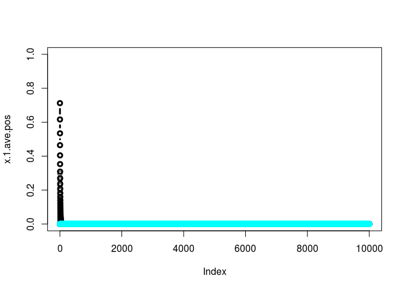